# miRNA data Analysis

Vijender Singh, CBC, UCHC

`2024-05-01

```r
rm(list=ls())
gc()
```

```
##          used (Mb) gc trigger (Mb) limit (Mb) max used (Mb)
## Ncells 527682 28.2    1172962 62.7         NA   669400 35.8
## Vcells 974003  7.5    8388608 64.0      16384  1851751 14.2
```

```r
knitr::opts_chunk$set(echo = TRUE, warning = FALSE)

# Load Packages
suppressPackageStartupMessages(library("tidyverse",quietly=TRUE))
suppressPackageStartupMessages(library("genefilter",quietly=TRUE))
suppressPackageStartupMessages(library("grDevices",quietly=TRUE))
suppressPackageStartupMessages(library("ggrepel",quietly=TRUE))
suppressPackageStartupMessages(library("pheatmap",quietly=TRUE))
suppressPackageStartupMessages(library("RColorBrewer",quietly=TRUE))
suppressPackageStartupMessages(library("gplots",quietly=TRUE))
suppressPackageStartupMessages(library("RColorBrewer", quietly=TRUE))
suppressPackageStartupMessages(library("ggplot2", quietly=TRUE))
suppressPackageStartupMessages(library("labeling", quietly=TRUE))
suppressPackageStartupMessages(library("DESeq2",quietly=TRUE))
suppressPackageStartupMessages(library("skimr",quietly=TRUE))
suppressPackageStartupMessages(library("here",quietly=TRUE))
suppressPackageStartupMessages(library("data.table",quietly=TRUE))

#Project Directory
projectDir=setwd(here("."))
print(paste0("Project Directory :", projectDir ))
```

```
## [1] "Project Directory :/Users/astral/Documents/DataAnalysis/Adelany_miRNA_Apr2024"
```

# RNAseq analysis : All Samples

## Data Import

#### Import Counts Matrix and Sample Metadata

The data is in tab-separated test (.txt) format. Data is imported using `fred` function from `data.table` package. The sample metadat is vaialable in `sampleTable.csv` file and is read in using `read.csv` function.

[output not shown]

|  | sample | Condition |
| --- | --- | --- |
| oldfrac_1 | oldfrac_1 | Old |
| oldfrac_2 | oldfrac_2 | Old |
| oldfrac_3 | oldfrac_3 | Old |
| oldfrac_4 | oldfrac_4 | Old |
| oldfrac_5 | oldfrac_5 | Old |
| youngfrac_6 | youngfrac_6 | Young |
| youngfrac_8 | youngfrac_8 | Young |
| youngfrac_10 | youngfrac_10 | Young |

#### Filtering

In this step we will filter out genes with very low counts across the samples. DESeq2 performs independent filtering but reducing the dimension of input dataset can speed up the process in large datasets.

```r
keep <- rowSums(countMat) >= 10
countMat<-countMat[keep,]

cat("\n Number of features after filteration : ", nrow(countMat))
```

```
##
##  Number of features after filteration :  825
```

## Counts QC

In this step we will perform few QC steps to check data completeness and will also try to identify if any sample is behaving odd from the raw counts perspective.

##### QC1. Sample checks

Test that all the input samples in sampleTable have their corresponding counts in the `counts` object.

```r
if (sum(colnames(countMat) %in% sampleTable$sample) == length(sampleTable$sample)){
  message("Good News !!! Samples in count matrix matches with that of in sampleTable")
}
```

```
## Good News !!! Samples in count matrix matches with that of in sampleTable
```

```r
cat("\n\n Matching order of samples between counts and sampleTable \n")
countMat<-countMat[sampleTable$sample]

cat("\n Is the sample orders identical between counts matrix and sampletable \n")
identical(colnames(countMat),sampleTable$sample)

cat("\n\n Convert metadata in categorical data whereever applicable\n")
sampleTable$Condition<-as.factor(sampleTable$Condition)

str(sampleTable)
```

```
##
##
##  Matching order of samples between counts and sampleTable
##
##  Is the sample orders identical between counts matrix and sampletable
## [1] TRUE
##
##
##  Convert metadata in categorical data whereever applicable
## 'data.frame':    8 obs. of  2 variables:
##  $ sample   : chr  "oldfrac_1" "oldfrac_2" "oldfrac_3" "oldfrac_4" ...
##  $ Condition: Factor w/ 2 levels "Old","Young": 1 1 1 1 1 2 2 2
```

##### QC2. QC of counts distribution per sample.

#### Sample: Count distribution Violin plot

##### **Violin Count Plot**

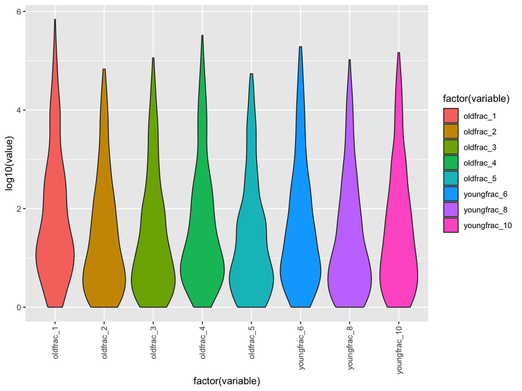

Quality check of samples to identify outliers or odd behaving samples.

```r
df_qc<-skim(countMat)
head(df_qc)
```

Data summary

| Name | countMat |
| --- | --- |
| Number of rows | 825 |
| Number of columns | 8 |
| _______________________ |  |
| Column type frequency: |  |
| numeric | 6 |
| ________________________ |  |
| Group variables | None |

**Variable type: numeric**

| skim_variable | n_missing | complete_rate | mean | sd | p0 | p25 | p50 | p75 | p100 | hist |
| --- | --- | --- | --- | --- | --- | --- | --- | --- | --- | --- |
| oldfrac_1 | 0 | 1 | 6201.29 | 38115.03 | 0 | 5 | 24 | 345 | 690852 | ▇▁▁▁▁ |
| oldfrac_2 | 0 | 1 | 1269.40 | 6024.48 | 0 | 2 | 8 | 90 | 67703 | ▇▁▁▁▁ |
| oldfrac_3 | 0 | 1 | 1613.95 | 8353.81 | 0 | 2 | 9 | 96 | 114050 | ▇▁▁▁▁ |
| oldfrac_4 | 0 | 1 | 3928.58 | 20991.33 | 0 | 4 | 17 | 204 | 327670 | ▇▁▁▁▁ |
| oldfrac_5 | 0 | 1 | 1039.27 | 4717.21 | 0 | 1 | 6 | 62 | 54531 | ▇▁▁▁▁ |
| youngfrac_6 | 0 | 1 | 3691.23 | 17929.47 | 0 | 4 | 18 | 190 | 192293 | ▇▁▁▁▁ |

##### **Counts Mean and Standard deviation plot**

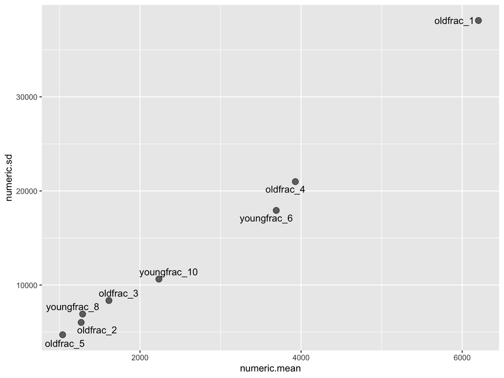

## DESeq2

##### Create DESeq2 Object

```r
# reassuring that order of samples in rows of sampleTable are identical with the sample order in count matrix
countMat<-countMat[sampleTable$sample]

dds <- DESeqDataSetFromMatrix(countData = as.matrix(countMat),
                              colData=sampleTable,
                              design = ~Condition)

# Setting "control" as baseline or reference
dds$Condition<-relevel(dds$Condition, ref=ref_level)

dds
```

```
## class: DESeqDataSet
## dim: 825 8
## metadata(1): version
## assays(1): counts
## rownames(825): mmu-miR-206-3p mmu-miR-133b-3p ... mmu-miR-98-5p
##   mmu-miR-98-3p
## rowData names(0):
## colnames(8): oldfrac_1 oldfrac_2 ... youngfrac_8 youngfrac_10
## colData names(2): sample Condition
```

##### Executing DESeq2

```r
dds<-DESeq(dds)
sizeFactors(dds)
```

```
##    oldfrac_1    oldfrac_2    oldfrac_3    oldfrac_4    oldfrac_5  youngfrac_6
##    2.3181684    0.6679599    0.7922614    1.5841280    0.5486988    1.6059991
##  youngfrac_8 youngfrac_10
##    0.5619579    1.1807142
```

Accessing results

```r
resultsNames(dds)
```

```
## [1] "Intercept"              "Condition_Young_vs_Old"
```

```r
## Access and saving normalised counts
normcounts<-as.data.frame(counts(dds,normalized =TRUE))
write.csv(normcounts,file="NormalisedCounts.csv")
```

## Sample QC

Sample to sample Distance Matrix

```r
rld <- rlogTransformation(dds, blind=T)
vsd <- varianceStabilizingTransformation(dds, blind=T)

sampleDists <- dist(t(assay(rld)))
sampleDistMatrix <- as.matrix(sampleDists)

sampleDistMatrix_meta<-merge(sampleDistMatrix,sampleTable, by=0, sort=FALSE) %>% column_to_rownames(., var="Row.names")

head(sampleDistMatrix_meta)
```

|  | oldfrac_1 | oldfrac_2 | oldfrac_3 | oldfrac_4 | oldfrac_5 | youngfrac_6 | youngfrac_8 | youngfrac_10 | sample | Condition |
| --- | --- | --- | --- | --- | --- | --- | --- | --- | --- | --- |
| oldfrac_1 | 0.00000 | 24.95453 | 27.28511 | 19.44508 | 23.35659 | 23.35200 | 31.19288 | 29.66229 | oldfrac_1 | Old |
| oldfrac_2 | 24.95453 | 0.00000 | 17.42382 | 19.72385 | 16.36214 | 17.17460 | 16.93074 | 16.51663 | oldfrac_2 | Old |
| oldfrac_3 | 27.28511 | 17.42382 | 0.00000 | 15.55196 | 19.74164 | 14.16891 | 18.02225 | 16.57741 | oldfrac_3 | Old |
| oldfrac_4 | 19.44508 | 19.72385 | 15.55196 | 0.00000 | 18.70995 | 15.19934 | 23.46823 | 22.14821 | oldfrac_4 | Old |
| oldfrac_5 | 23.35659 | 16.36214 | 19.74164 | 18.70995 | 0.00000 | 19.11467 | 21.94613 | 20.26874 | oldfrac_5 | Old |
| youngfrac_6 | 23.35200 | 17.17460 | 14.16891 | 15.19934 | 19.11467 | 0.00000 | 17.85094 | 14.14303 | youngfrac_6 | Young |

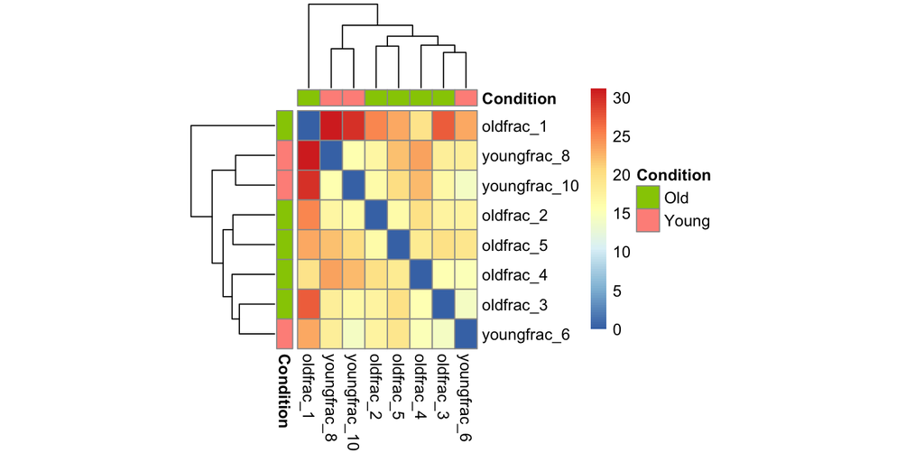

Principal component Analysis

Principal Component Analysis (PCA) is a widely used statistical method in the analysis of differential gene expression data. It helps in understanding the underlying structure of high-dimensional data, like gene expression profiles, by reducing its complexity. PCA achieves this by transforming the original variables into a new set of uncorrelated variables called principal components, which are ordered so that the first few retain most of the variation present in all of the original variables.

In the context of differential gene expression, PCA is particularly useful for several reasons:

1. Data Visualization: PCA allows for the visualization of complex gene expression data in two or three dimensions. This can help in identifying patterns, trends, or clusters in the data that might indicate similarities or differences in gene expression under various conditions or among different samples.
2. Noise Reduction: By focusing on principal components that capture the most variance, PCA can help filter out noise and reduce the dimensionality of the data, making further analysis more tractable.
3. Identification of Important Genes: The loading scores of the principal components can be used to identify genes that contribute most to the variance in the data. These genes can be candidates for further study as they might play significant roles in the biological processes or conditions being studied.
4. Batch Effect Correction: PCA can help in identifying and correcting for batch effects, which are technical non-biological differences between batches of samples that can affect gene expression levels.
5. Comparative Analysis: By comparing the PCA results of different conditions or experiments, researchers can identify shifts in the principal component space, indicating changes in gene expression profiles associated with different biological states or treatments.

```r
rv <- rowVars(assay(rld))
select <- order(rv, decreasing=T)[seq_len(min(100,length(rv)))]
pc <- prcomp(t(assay(vsd)[select,]))
scores <- data.frame(pc$x)
scores<-cbind(scores,sampleTable)
summary(pc)
```

```
## Importance of components:
##                           PC1    PC2     PC3    PC4     PC5     PC6     PC7
## Standard deviation     9.7791 5.2446 3.60360 3.0833 2.39709 1.82514 1.38603
## Proportion of Variance 0.6106 0.1756 0.08291 0.0607 0.03669 0.02127 0.01227
## Cumulative Proportion  0.6106 0.7862 0.86908 0.9298 0.96647 0.98773 1.00000
##                              PC8
## Standard deviation     6.478e-15
## Proportion of Variance 0.000e+00
## Cumulative Proportion  1.000e+00
```

```r
pc1prcnt=as.character(as.integer(summary(pc)$importance[2,1]*100))
pc2prcnt=as.character(as.integer(summary(pc)$importance[2,2]*100))
pc3prcnt=as.character(as.integer(summary(pc)$importance[2,3]*100))
pc4prcnt=as.character(as.integer(summary(pc)$importance[2,4]*100))
pc5prcnt=as.character(as.integer(summary(pc)$importance[2,5]*100))
pc6prcnt=as.character(as.integer(summary(pc)$importance[2,6]*100))

names<-rownames(scores)

pc12 <-ggplot(scores, aes(x = PC1, y = PC2, label=sample,col = (factor(Condition))))+
  geom_point(size = 5)+
  geom_text_repel(label=names,col="black")+
  ggtitle("Principal Components")+
  xlab(paste0("PC1 (",pc1prcnt,"%)")) +
  ylab(paste0("PC2 (",pc2prcnt,"%)"))

pc34 <-ggplot(scores, aes(x = PC3, y = PC4, label=sample,col = (factor(Condition))))+
  geom_point(size = 5)+
  geom_text_repel(label=names,col="black")+
  ggtitle("Principal Components")+
  xlab(paste0("PC3 (",pc3prcnt,"%)")) +
  ylab(paste0("PC4 (",pc4prcnt,"%)"))

pc56 <-ggplot(scores, aes(x = PC5, y = PC6, label=sample,col = (factor(Condition))))+
  geom_point(size = 5)+
  geom_text_repel(label=names,col="black")+
  ggtitle("Principal Components")+
  xlab(paste0("PC5 (",pc5prcnt,"%)")) +
  ylab(paste0("PC6 (",pc6prcnt,"%)"))
```

### PCA Plots

#### Plot PC12

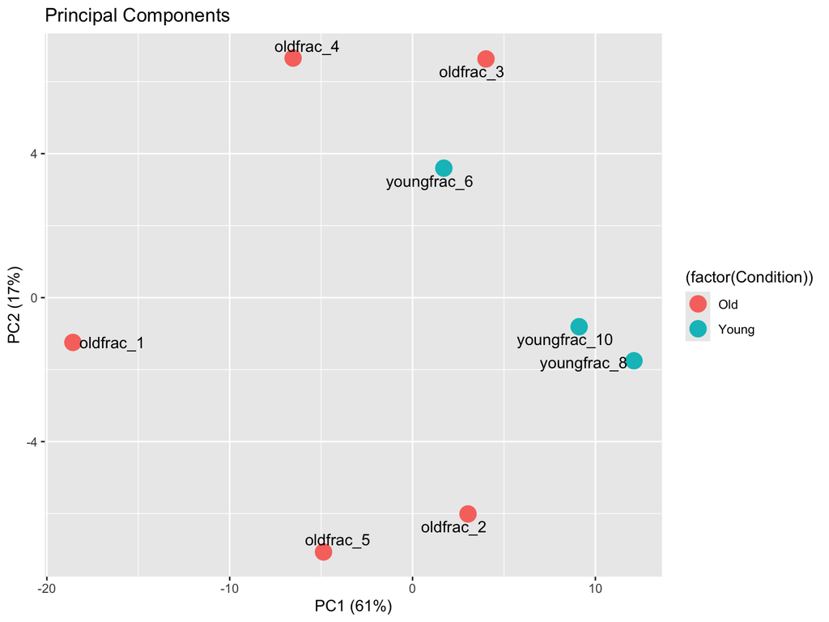

#### Plot PC34

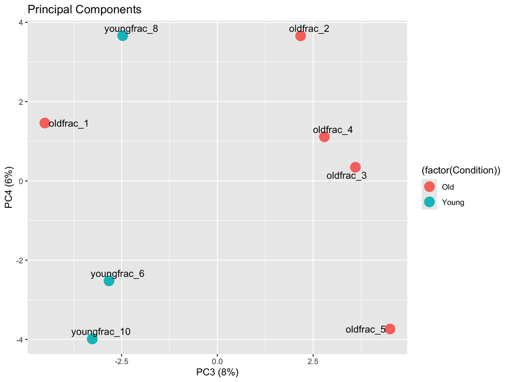

#### Plot PC56

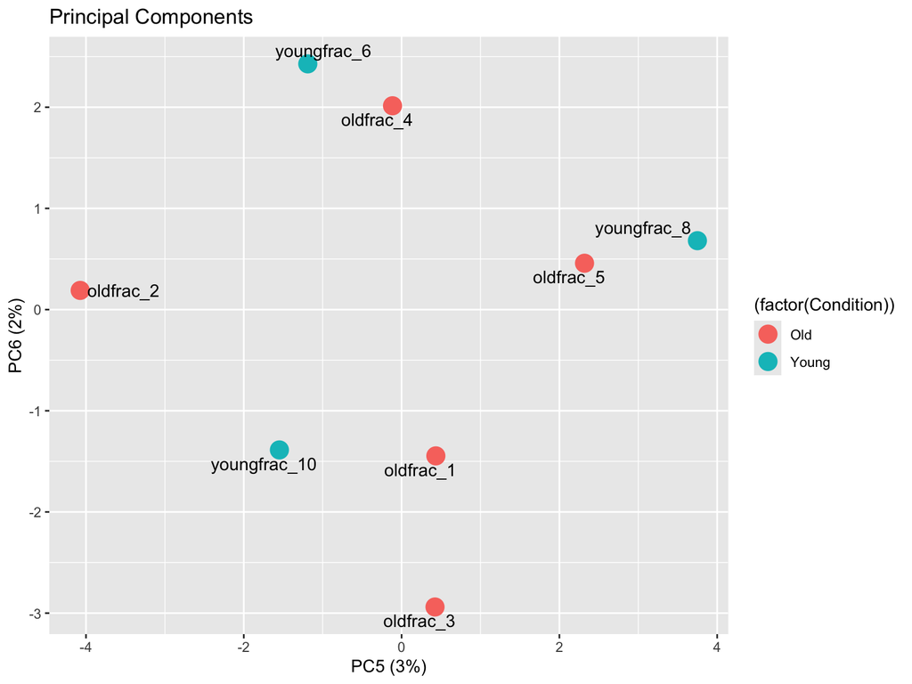

```r
res<-as.data.frame(results(dds, name = "Condition_Young_vs_Old"))

write.csv(res, file="AllDetectedFeatures_DE.csv")

resOrdered <- res[order(res$padj),]
resOrdered
```

|  | baseMean | log2FoldChange | lfcSE | stat | pvalue | padj |
| --- | --- | --- | --- | --- | --- | --- |
| mmu-miR-19a-5p | 3.792237e+01 | -2.500991689 | 0.5040063 | -4.962223335 | 6.969080e-07 | 0.0003407880 |
| mmu-miR-296-5p | 7.319779e+01 | 2.752382801 | 0.5735943 | 4.798483564 | 1.598714e-06 | 0.0003908856 |
| mmu-miR-130b-5p | 8.978992e+01 | -1.988594936 | 0.4556514 | -4.364290472 | 1.275360e-05 | 0.0020788372 |
| mmu-miR-223-5p | 2.304241e+03 | -2.709580909 | 0.7010817 | -3.864857471 | 1.111541e-04 | 0.0135885873 |
| mmu-miR-92a-1-5p | 8.764938e+01 | -1.597991029 | 0.4380897 | -3.647633981 | 2.646663e-04 | 0.0258843648 |
| mmu-miR-18a-5p | 2.459549e+02 | -2.301392268 | 0.6489960 | -3.546080839 | 3.910062e-04 | 0.0318670085 |
| mmu-miR-673-3p | 6.876745e+00 | 3.453512666 | 1.0213669 | 3.381265583 | 7.215277e-04 | 0.0448736125 |
| mmu-miR-146b-5p | 2.258398e+03 | -2.035349665 | 0.6027976 | -3.376505655 | 7.341286e-04 | 0.0448736125 |
| mmu-miR-7a-5p | 1.433387e+04 | -1.853650498 | 0.5649473 | -3.281103238 | 1.034019e-03 | 0.0506951397 |
| mmu-miR-703 | 2.815941e+01 | -1.923508505 | 0.5863694 | -3.280369965 | 1.036710e-03 | 0.0506951397 |

[output cut: 815 more lines]

```r
write.csv(resOrdered, file="AllDetectedFeatures_DE_padjSorted.csv")

resSign <- res[res$pvalue<0.05 & abs(res$log2FoldChange)>1,]
write.csv(resSign, file="Pval_0.05_log2FC_1_significant_features.csv")
```